# WAICのおさらい2

UPDATE: 2024-02-22 23:34:23.555696

# はじめに

- [社会科学のためのベイズ統計モデリング](https://www.asakura.co.jp/detail.php?book_code=12842)

今回は情報量から初めて、WAICの導出までを行う。

## 6.2 情報量

確率の対数をとって符号変換した関数である。

情報量

離散確率変数$X$の実現値$x$が生起した時の情報量を
$$\begin{eqnarray}
I(X=x) = -log P(X=x)
\end{eqnarray}$$
と定義する。

確率が低いと情報量が多く、確率が高いと情報量が低い。

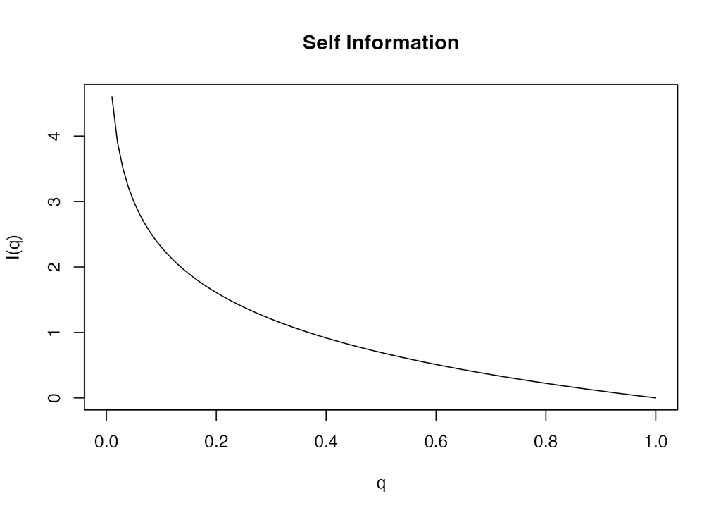

```r
q <- seq(0, 1, 0.01)
plot(
  q,
  -log(q),
  type = 'l',
  xlab = 'q',
  ylab = 'I(q)',
  main = 'Self Information'
)
```

## 6.3 エントロピー

ベルヌイ分布に従う確率変数について考える。

$$\begin{eqnarray}
Y \sim Bernoulli(q)
\end{eqnarray}$$
1が出る確率$I(Y=1)=0.01$が低い場合、$I(Y=1)=-log0.01=4.61$となり、1が出た時の情報量が大きいが、確率が低いため、このような情報を得る期待は低い。一方で、0が出る確率$I(Y=0)=0.99$が高い場合、$I(Y=0)=-log0.99=0.01$となり、0が出た時の情報量が低いが、確率が高いため、このような情報を得る期待は高い。

そのため、情報量の期待値を定義し、確率試行において期待される情報量を測る。これはエントロピー、平均情報量と呼ばれる。

エントロピー

離散確率変数$X$のエントロピー$H(X)$を情報量の期待値として、
$$\begin{eqnarray}
H(X) &=& \mathbb{E}[I(X)] \\
&=& - \sum_{i=1}^{n} P(X=x_i)log P(X=x_i)
\end{eqnarray}$$
と定義する。$P(X=x_i)=0$のとき0とする。下記で表現される場合もある。
$$\begin{eqnarray}
H(f) &=& - \sum_{i=1}^{n} f(x_i)log f(x_i)
\end{eqnarray}$$

連続確率変数$X$のエントロピー$H(X)$は、
$$\begin{eqnarray}
H(X) &=& \mathbb{E}[H(X)] \\
&=& - \int_{A} f(x)logf(x)dx
\end{eqnarray}$$
と定義する。

ベルヌイ確率変数のエントロピーは$q=0.5$のとき、最大となる。$q=0.5$のときのエントロピーが高いため、一番不確実性が高く、0か1のどちらがでやすいのか判断できない。つまり、情報量が大きいと予測できない。

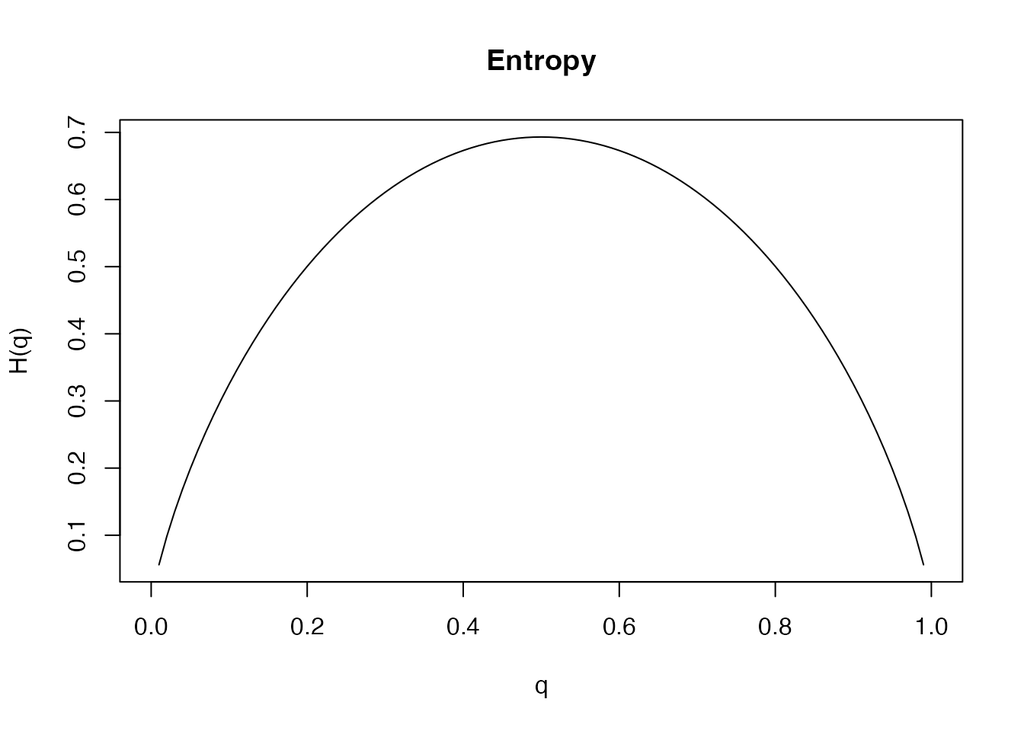

```r
plot(
  q,
  -q*log(q)-(1-q)*log(1-q),
  type = 'l',
  xlab = 'q',
  ylab = 'H(q)',
  main = 'Entropy'
)
```

正規分布に従う確率変数であれば、エントロピーは標準偏差$\sigma$の増加関数となる。つまり、標準偏差$\sigma$が大きくなると、エントロピーが大きくなり、平均$\mu$周りの値が出にくくなる。結果、不確実性が高まり、予測ができにくくなる。

## 6.5 KL情報量

KL情報量(カルバック・ライブラー情報量)を考える。KL情報量は2つの確率分布を比較し、近さを考えるために使われる。

KL情報量

連続確率密度関数$q(x),p(x)>0$についてのKL情報量を
$$\begin{eqnarray}
D(q||p) &=& \int_{A} q(x) log \frac{q(x)}{p(x)} dx
\end{eqnarray}$$
と定義する。

KL情報量は連続確率密度関数$q(x),p(x)$の比の対数を情報量とみて、その期待値を$q(x)$で取ったもので、相対エントロピーとも呼ばれる。下記の性質をもつ。

- 任意の$q(x),p(x)$について$D(q||p) \ge 0$
- $q(x)=p(x)$のとき$D(q||p) = 0$

これらにより、2つの分布が等しいとき、KL情報量は0となる。下記は正規分布と標準正規分布のKL情報量を可視化したもの。正規分布の$\sigma=1$に固定して$\mu$を変数としたとき、$\mu=0$でKL情報量が0となる。

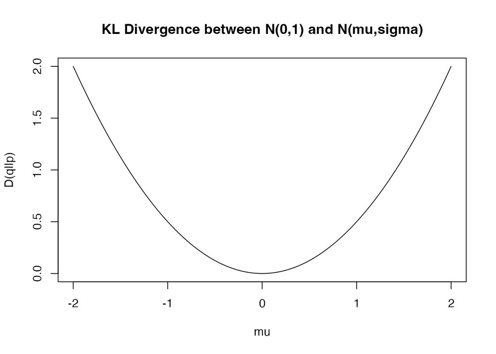

```r
mu <- seq(-2,2,0.01)
sigma <- 1
plot(
  mu,
  -1/2 + 1/(2*sigma^2)*(1+mu^2) + log(sigma),
  type = 'l',
  xlab = 'mu',
  ylab = 'D(q||p)',
  main = 'KL Divergence between N(0,1) and N(mu,sigma)'
)
```

正規分布の$\mu=0$に固定して$\sigma$を変数としたとき、$\sigma=1$でKL情報量が0となる。

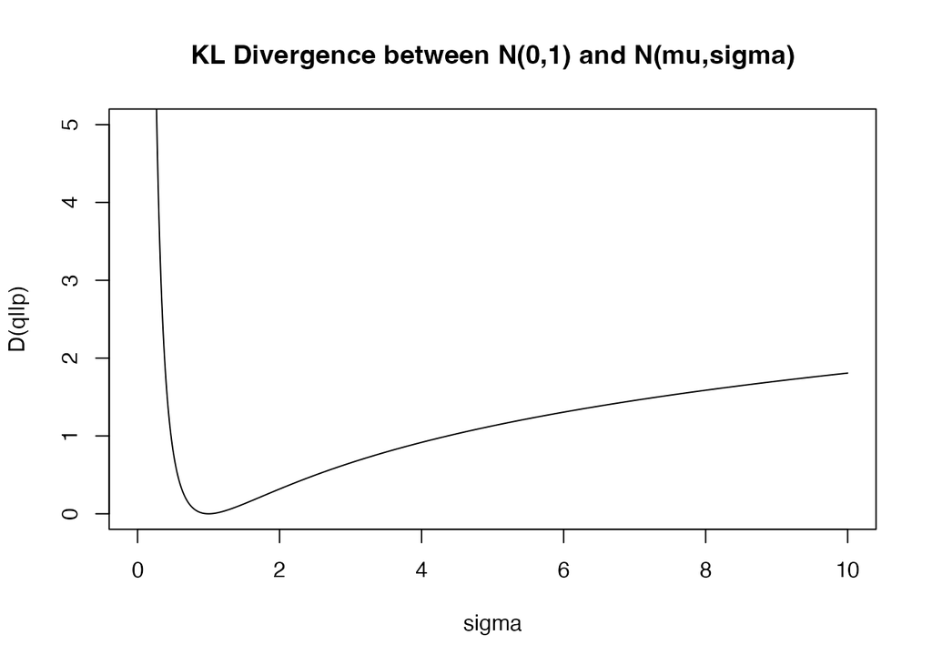

```r
mu <- 0
sigma <- seq(0,10,0.01)
plot(
  sigma,
  -1/2 + 1/(2*sigma^2)*(1+mu^2) + log(sigma),
  type = 'l',
  xlab = 'sigma',
  ylab = 'D(q||p)',
  main = 'KL Divergence between N(0,1) and N(mu,sigma)',
  ylim = c(0,5)
)
```

## 6.6 交差エントロピー

KL情報量と関連する交差エントロピーを考える。

交差エントロピー

連続確率密度関数$q(x),p(x)>0$についての交差エントロピーを
$$\begin{eqnarray}
H_q(p) &=& -\int_{A} q(x) log p(x) dx
\end{eqnarray}$$
と定義する。

交差エントロピーは$q(x)$が真の分布であるとき、情報量として$log p(x)$を仮定することで得られる平均情報量である。また、KL情報量$D(q||p)$は、変形すると交差エントロピーと$H_q(p)$と真の分布のエントロピー$H(q)$に分解できる。

$$\begin{eqnarray}
D(q||p) &=& -\int_{A} q(x) \frac{q(x)}{p(x)} dx \\
&=& -\int_{A} q(x) logp(x) dx + \int_{A} q(x) logq(x) dx \\
&=& H_q(p) - H(q)
\end{eqnarray}$$

つまり、交差エントロピー$H(q)$は、未知の真の分布$q(x)$のエントロピーとKL情報量に分解できる。

$$\begin{eqnarray}
H_q(p) &=& H(q) + D(q||p)
\end{eqnarray}$$

真の分布$q(x)$のエントロピーは未知ではあるものの定数である。つまり、真の分布からモデル$p(x)$の近さ$D(q||p)$は、未知の真の分布$q(x)$のエントロピーを除けば、交差エントロピー$H_q(p)$の大きさと一致する。これにより、交差エントロピーをデータから推定できれば、モデルの真の分布への相対的な近さを評価できる。

## 6.7 汎化損失

なんらかの確率モデルとデータから得た予測分布$p^{*}(x)$を考える。真の分布$q(x)$と予測分布$p^{*}(x)$の交差エントロピー$H_q(p^{*})$を汎化損失$G_n$と呼ぶ。

汎化損失

$$\begin{eqnarray}
G_n &=& - \mathbb{E}_{q(X)}[\log p^{*}(X)] \\
&=& - \int \log p^{*}(x) q(x) dx \\
&=& \underbrace{H(q)}_{真の分布のエントロピー} +
\underbrace{D(q||p^{*})}_{真の分布と予測分布のKL情報量}
\end{eqnarray}$$
と定義する。

汎化損失$G_n$は$q(x)$のエントロピーにおいて、$-logp^{*}(x)$を仮定した情報量といえる。また、予測分布$p^{*}(x)$の導出に用いた$x^{n}=(x_1,...,x_n)$を入れて、相加平均を計算したものを、経験損失$T_n$と呼ぶ。

$$\begin{eqnarray}
T_n &=& - \frac{1}{n} \sum_{i}^{n} logp^{*}(x_i)
\end{eqnarray}$$

経験損失$T_n$を使って、汎化損失$G_n$を推定する方法として、最尤推定予測分布についてのAIC、WAICを導入する。

## 6.8 AIC

最尤法を用い、下記を仮定する。

- 真の分布$q(x)=p(x|\theta)$。つまり、想定される確率モデルの中に真の分布が含まれる。実現可能性が存在する。
- サンプル$X^n \sim q(x^n) = \prod q(x)$は、独立かつ同一の真の分布に従う。
- 確率モデル$p(x^n|\theta)$
- $q(x)$は確率について正則と仮定する。最尤推定量が一致性と漸近正規性を持つための条件。

サンプル$X^n$の実現値$x^n$が与えられたとき、最尤推定量$\hat{\theta}$は、確率モデルの$\theta$について最大化問題として、

$$\begin{eqnarray}
\hat{\theta} = arg \ max p(x^n| \theta)
\end{eqnarray}$$

と解くことができる。最尤推定値を用いた予測分布は$p^{*}(x) = p(x| \hat{\theta})$である。最尤推定のとき、汎化損失は

$$\begin{eqnarray}
G_n &=& - \mathbb{E}_{q(X)}[\log p^{*}(X)] \\
&=& - \mathbb{E}_{q(X)}[\log p(X| \hat{\theta})] \\
&=& - \int \log p(x| \hat{\theta})q(x)dx
\end{eqnarray}$$

となる。これは平均対数尤度の符号を反転させたものに一致する。一般的には平均対数尤度が大きくなるほど、汎化損失は小さくなる。つまり、平均対数尤度は予測のよさを示す。一方、最尤推定において経験損失は、

$$\begin{eqnarray}
T_n &=& - \frac{1}{n} \log p(x^n|\theta) \\
&=& - \frac{1}{n} \underbrace{\sum \log
p(x_i|\hat{\theta})}_{最大対数尤度}
\end{eqnarray}$$

経験損失はデータから計算できるので、汎化損失を推定できる。ただし、予測分布の導出に使用したデータを再び使用する経験損失は何らかのバイアス$b(x^n)$が生じている可能性がある。

$$\begin{eqnarray}
b(x^n) &=& G_n - T_n \\
&=& - \mathbb{E}_{q(X)}[\log p(X|\hat{\theta})] + \frac{1}{n}
\log p(x^n|\hat{\theta}) \\
\end{eqnarray}$$

この偏りはデータの出方やそのデータから計算される最尤推定量$\hat{\Theta}$などの確率変数に影響される。そのため、偏りの期待値を考える。$Z$は予測する新たな確率変数。

$$\begin{eqnarray}
\mathbb{E}_{q(X^n)}[b(x^n)] &=& \mathbb{E}_{q(X^n)}[G_n - T_n]
\\
&=& \mathbb{E}_{q(X^n)}[- \mathbb{E}_{q(Z)}[\log
p(Z|\hat{\theta})] + \frac{1}{n} \log p(x^n|\hat{\theta})]\\
\end{eqnarray}$$

最大対数尤度と平均対数尤度を$n$倍したものの間の偏りの期待値は、想定した確率モデルに真の分布が含まれるという過程の下で、漸近的に自由パラメタ数$d$に一致する。そして、汎化損失と経験損失のバイアスの期待値$\mathbb{E}_{q(X^n)}[b(x^n)]$は漸近的に$\frac{d}{n}$に一致する。以上より、AICは、

AIC

$$\begin{eqnarray}
AIC &=& T_n + \frac{d}{n}\\
&=& -\frac{1}{n} \sum \log p(x_i|\hat{\theta}) + \frac{d}{n}\\
\end{eqnarray}$$

と定義される。AICは漸近的に平均的に汎化損失に一致する、つまり、AICは汎化損失の良い近似となる。

## 6.9 WAIC

ベイズモデルにおける汎化損失について考える。下記を仮定する。

- 真の確率分布$q(x)$は想定される確率モデルの中に真の分布が含まれてなくてもよい。
- サンプル$X^n \sim q(x^n) = \prod q(x)$は、独立同一の分布を仮定する。
- 確率モデル$p(x^n|\theta)$
- パラメタの事前分布$\varphi(\theta)$
- $q(x)$は確率について正則でなくてもよい

ベイズ推定をもとにした予測分布は、確率モデルを事後分布によって期待値を取ったものとして、

$$\begin{eqnarray}
p^{*}(x) &=& \mathbb{E}_{p(\theta|x^n)}[p(x|\theta)] \\
&=& \int p(x|\theta) p(\theta|x^n) d\theta
\end{eqnarray}$$

定義される。ベイズ予測分布についての汎化損失$G_n$は、

$$\begin{eqnarray}
G_n &=& -\mathbb{E}_q(X)[ \log p^*(X)] \\
&=& -\mathbb{E}_q(X)[ \log
\mathbb{E}_{p(\theta|x^n)}[p(X|\theta)]] \\
&=& -\int q(x) \log \left( \int p(x|\theta) p(\theta|x^n)
d\theta\right)dx
\end{eqnarray}$$

で、ベイズ予測分布の経験損失$T_n$は、

$$\begin{eqnarray}
T_n &=& -\frac{1}{n} \sum \log p^*(x_i) \\
&=& -\frac{1}{n} \sum \log
\mathbb{E}_{p(\theta|x^n)}[p(x_i|\theta)] \\
\end{eqnarray}$$

AIC同様、経験損失は何らかのバイアス$b(X^n)$が生じている可能性がある。このバイアスの期待値は、

$$\begin{eqnarray}
\mathbb{E}_{q(X^n)}[b(X^n)] &=& \mathbb{E}_{q(X^n)}[G_n - T_n]
\\
\end{eqnarray}$$

であり、このバイアスの期待値は汎関数分散$V_n$を$n$で割った$\frac{V_n}{n}$と漸近的に一致する。

$$\begin{eqnarray}
V_n &=&
\sum_{i}^{N} \left\{ \mathbb{E}_{p(\theta|x^n)} \left[ (\log
p(x_i|\theta))^{2} \right] - \mathbb{E}_{p(\theta|x^n)} \left[ (\log
p(x_i|\theta) \right]^{2} \right\} \\
\end{eqnarray}$$

以上よりWAICは、経験損失と汎関数分散を$n$で割った値の和として定義される。

$$\begin{eqnarray}
WAIC &=& T_n + \frac{V_n}{n} \\
&=& -\frac{1}{n} \sum \log
\mathbb{E}_{p(\theta|x^n)}[p(x_i|\theta)] +
\sum \left\{ \mathbb{E}_{p(\theta|x^n)} \left[ (\log p(x_i|\theta))^{2}
\right] - \mathbb{E}_{p(\theta|x^n)} \left[ (\log p(x_i|\theta)
\right]^{2} \right\} \\
\end{eqnarray}$$

## WAICを計算する

ここでは、カウントデータに対して、ガンマ-ポアソン分布を用いてモデル化を行い、WAICを計算する。

$$\begin{eqnarray}
X &\sim& Poisson(\lambda) \\
\lambda &\sim& Gamma(a,b) \\
\end{eqnarray}$$

これらの分布は共役関係から下記の通り事後分布が計算できる。これは$a_n = \sum x_i + a, b_n = n + b$のガンマ分布と一致する。

$$\begin{eqnarray}
p(\lambda|x^n) = \frac{b_{n}^{a_n}}{\Gamma(a_n)} \lambda^{a_{n} -1}
e^{-b_{n} \lambda}
\end{eqnarray}$$

ここでは真の分布は$\lambda^*=3$のポアソン分布とする。確率モデルにポアソン分布、事前分布に$a=3,b=1$のガンマ分布を考える。事後分布を使った事後予測分布は、

$$\begin{eqnarray}
p^*(x) &=& \int_0^{\infty} P(x|\lambda) p(\lambda|x^n) d\lambda
\\
&=& \int_0^{\infty} \frac{1}{x!}\lambda^x e^{-\lambda}
\frac{b_{n}^{a_n}}{\Gamma(a_n)} \lambda^{a_{n} -1} e^{-b_{n} \lambda}
d\lambda \\
&=& \frac{\Gamma(x +
a_n)}{\Gamma(a_n)x!}\frac{b_{n}^{a_n}}{(1+b_n)^{x+a_n}}
\end{eqnarray}$$

である。さらにここから、負の二項分布の確率分布を導出できる。つまり、事後予測分布は解析的に負の二項分布として導ける。また、予測分布の情報量は、下記となる。

$$\begin{eqnarray}
-\log p^*(x) &=& -log \left( \frac{\Gamma(x +
a_n)}{\Gamma(a_n)x!}\frac{b_{n}^{a_n}}{(1+b_n)^{x+a_n}}\right) \\
&=& -\log \Gamma(x+a_n) + \log\Gamma(a_n) + logx! - a_n \log b_n
+ (x+a_n) \log(1+b_n)
\end{eqnarray}$$

汎化損失$G_n$は真の分布として、$\lambda^*=3$のポアソン分布を仮定しているため、

$$\begin{eqnarray}
G_n &=& \int - \log p^*(x) q(x) dx \\
&=& \sum - \log p^*(x_i) Poisson(x_i|\lambda) \\
&=& \sum \frac{1}{x_i!} (\lambda^*)^{x_i} e^{-\lambda^*} [-\log
\Gamma(x_i + a_n) + \log (a_n) + log x_i! - a_n \log b_n + (x_i+a_n)
\log(1+b_n)] \\
\end{eqnarray}$$

となる。WAICを計算するためには経験損失と汎関数分散が必要。経験損失は予測分布の情報量を使えば計算できる。

$$
$$\begin{eqnarray}
T_n &=& \frac{1}{n} \sum -\log p^*(x_i) \\
&=& \frac{1}{n} \sum [-\log \Gamma(x_i + a_n) + \log (a_n) + log
x_i! - a_n \log b_n + (x_i+a_n) \log(1+b_n)] \\
V_n &=& \sum \left[
\int \log (Poisson(x_i|\lambda))^2 p(\lambda|x^n) d\lambda - \left( \int
\log Poisson(x_i|\lambda) p(\lambda|x^n) d\lambda \right)^{2}
\right]
\end{eqnarray}$$
$$

解析的には計算できないので、MCMCのサンプルを利用して計算する。データ点ごとにMCMCサンプルから計算した対数尤度を用いる。MCMCサンプルが数が$S$個あり、$s$番目のパラメタ$\theta$の事後分布のMCMCサンプルを$\theta_s$とする。経験損失は、

$$\begin{eqnarray}
T_n &\approx& \frac{1}{n} \sum_{i}^{N}\left[ -\log
\left(\frac{1}{S} \sum^S p(x_i|\theta_s)\right) \right]
\end{eqnarray}$$
である。$()$内は、尤度関数を事後分布で平均した値、つまり予測分布を近似している。汎関数分散は、

$$\begin{eqnarray}
V_n &\approx& \sum_{i}^{N} \left[
\ \frac{1}{S-1} \sum_{s}^{S} \log p(x_i|\theta_s)^2 - \left(
\frac{1}{S-1} \sum_{s}^{S} \log p(x_i|\theta_s) \right)^{2}
\right]
\end{eqnarray}$$
となる。$[]$内は、事後分布で平均した尤度尤度の分散を近似している。これをRで実装していく。

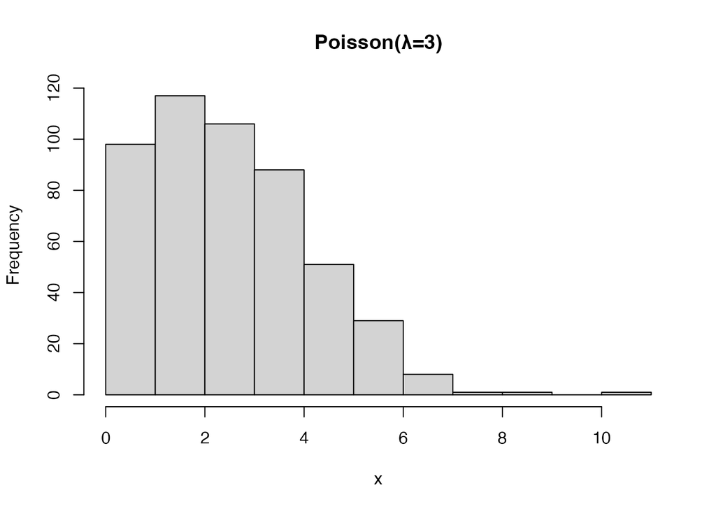

```r
library(tidyverse)
library(rstan)
library(loo)

options(max.print = 999999)
rstan_options(auto_write=TRUE)
options(mc.cores=parallel::detectCores())

lambda_prime <- 3
n <- 500
a <- 3
b <- 1
set.seed(1989)
x <- rpois(n, lambda_prime) #q(x)
hist(x, main = 'Poisson(λ=3)')
```

各種、計算に必要な関数を定義する。

```r
WAIC <- function(x){
  return(T_n(x) + V_n(x)/length(x))
}

T_n <- function(x){
  temp <- c()
  for(i in 1:length(x)){
    temp[i] = i_pred_dist(x[i],x)
  }
  return(mean(temp))
}

V_n <- function(x){
  a_n <- sum(x)+a
  b_n <- length(x)+b
  V_comp <- function(x){
    poisgamma <- function(lambda){
      dpois(x,lambda,log=T)*dgamma(lambda,a_n,b_n)
    }
    poisgamma2 <- function(lambda){
      dpois(x,lambda,log=T)^2*dgamma(lambda,a_n,b_n)
    }
    temp1 <- integrate(poisgamma2,0,Inf)$value
    temp2 <- integrate(poisgamma,0,Inf)$value
    return(temp1-temp2^2)
  }
  temp <- c()
  for(i in 1:length(x)){
    temp[i] <- V_comp(x[i])
  }
  return(sum(temp))
}

waic_mcmc <- function(log_lik){
  T_n <- mean(-log(colMeans(exp(log_lik))))
  V_n_divide_n <- mean(apply(log_lik,2,var))
  waic <- T_n + V_n_divide_n
  return(waic)
}

G_n <- function(lambda_prime,x){
  temp <- 0
  for(j in 0:20){
    temp = temp + dpois(j,lambda_prime)*i_pred_dist(j,x)
  }
  return(temp)
}

i_pred_dist <- function(x_d,x){
  a_n <- sum(x)+a
  b_n <- length(x)+b
  return(-lgamma(x_d+a_n) + lgamma(a_n)+lgamma(x_d+1) - a_n*log(b_n) + (x_d+a_n)*log(1+b_n))
}
```

モデルはこちら。WAICを計算するために`poisson_lpmf()`関数からのサンプリングを行っておく。

```
data{
  int N;
  int X[N];
  real a;
  real b;
}

parameters{
  real<lower=0> lambda;
}

model{
  for(i in 1:N){
    X[i] ~ poisson(lambda);
  }
  lambda ~ gamma(a,b);
}

generated quantities{
  real log_lik[N];
  for(i in 1:N){
    log_lik[i] = poisson_lpmf(X[i]|lambda);
  }
}
```

先にコンパイルしてから、

```r
model.waic <- stan_model('poisson_WAIC.stan')
```

`sampling()`関数でサンプリングする。複数回のシュミレーションを行うことで、WAICが汎化損失のよい近似となるかを確認する。

```r
sim_n <- 50
G_n_e <- WAIC_mcmc <- WAIC_e <- vector(mode = 'numeric', length = sim_n)
set.seed(1989)

for(i in 1:sim_n){
  x <- rpois(n, lambda_prime)
  WAIC_e[i] <- WAIC(x)
  fit.waic <- sampling(model.waic, data = list(N = n, X = x, a = a, b = b))
  log_lik <- rstan::extract(fit.waic)$log_lik
  WAIC_mcmc[i] <- waic_mcmc(log_lik)
  G_n_e[i] <- G_n(lambda_prime,x)
}
```

シュミレーションされた値の平均はこちら。

```r
list(
  WAIC_e = mean(WAIC_e),
  WAIC_mcmc = mean(WAIC_mcmc),
  G_n_e = mean(G_n_e)
)
```

[output not shown]

可視化しておく。今回のシュミレーションでは良い近似となっていることがわかる。

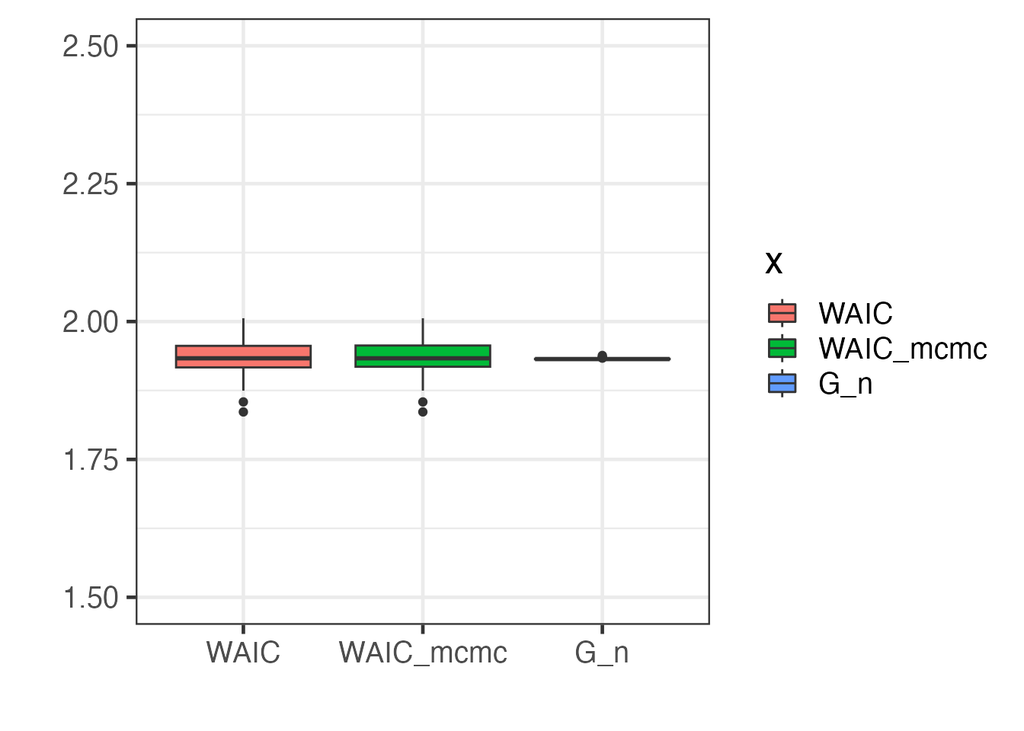

```r
tibble(
  WAIC = WAIC_e,
  WAIC_mcmc = WAIC_mcmc,
  G_n = G_n_e
  ) %>%
  gather(key = "x", value = "y") %>%
  mutate(x = forcats::fct_inorder(x)) %>%
  ggplot() +
  theme_bw(base_size = 18) +
  geom_boxplot(aes(x, y, fill = x)) +
  xlab('') + ylab('') + ylim(1.5, 2.5)
```

WAICが最小だからといいて、最良のモデル化はわからない点は注意が必要。あくまでも比較したモデルの中での相対的な良さである。

## 参考文献および参考資料

- [社会科学のためのベイズ統計モデリング](https://www.asakura.co.jp/detail.php?book_code=12842)
- [AIC, WAIC, WBICを実感する](https://rpubs.com/aishida/AIC_WAIC_WBIC)